# Dashboard Starter

## Where this fits

This is the **required core artifact** for Assignment 7. The Shiny exemplar shown in class is a demonstration only; adapt this Quarto file instead.

## Goal

This starter shows how to turn the Week 7 descriptive summary into a dashboard-style KT product. It uses one editable control value, one visualization, one table, one interpretation, and one caution — the 1-1-1-1-1 rule made concrete.

## Audience Question

Audience: a public-health analyst preparing a short briefing on descriptive BMI patterns in the classroom NHANES equity dataset.

Question: among adults age 20-80, how does mean BMI vary across NHANES cycles for one selected income group?

## Setup

```r
library(tidyverse)
library(knitr)

candidate_paths <- c(
  "examples/nhanes-equity/data/nhanes_equity_v6.csv",
  "../../examples/nhanes-equity/data/nhanes_equity_v6.csv"
)

data_path <- candidate_paths[file.exists(candidate_paths)][1]
if (is.na(data_path)) {
  stop("Could not find examples/nhanes-equity/data/nhanes_equity_v6.csv")
}

nhanes <- read_csv(data_path, show_col_types = FALSE)
```

## Control

In a Shiny app, this would become a dropdown. In this static starter, change the value of `selected_income` and render again.

```r
available_income_groups <- sort(unique(na.omit(nhanes$IncomeGroup)))
selected_income <- "Middle Income"

if (!selected_income %in% available_income_groups) {
  selected_income <- available_income_groups[1]
}

selected_income
```

```
[1] "Middle Income"
```

## Summary

```r
dashboard_summary <- nhanes |>
  filter(
    Age >= 20,
    Age <= 80,
    IncomeGroup == selected_income,
    !is.na(BMI),
    !is.na(Cycle)
  ) |>
  group_by(Cycle) |>
  summarise(
    n = n(),
    mean_bmi = round(mean(BMI), 1),
    .groups = "drop"
  )

kable(dashboard_summary)
```

| Cycle | n | mean_bmi |
| --- | --- | --- |
| 1999-2000 | 1327 | 29.0 |
| 2001-2002 | 1561 | 28.3 |
| 2003-2004 | 1573 | 28.8 |
| 2005-2006 | 1629 | 29.1 |
| 2007-2008 | 1982 | 29.1 |
| 2009-2010 | 2030 | 29.3 |
| 2011-2012 | 1630 | 28.9 |
| 2013-2014 | 1749 | 29.6 |
| 2015-2016 | 1925 | 29.7 |
| 2017-2018 | 1857 | 30.2 |
| 2021-2023 | 1965 | 30.3 |

## Visualization

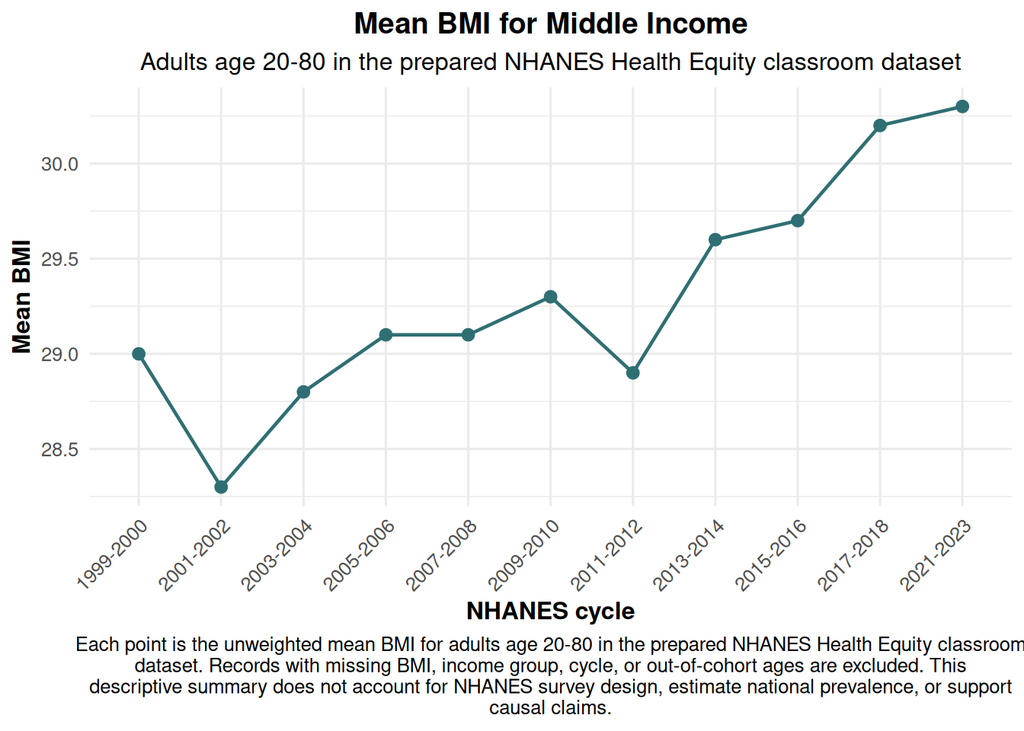

```r
# AI prompt: Make the chart caption clearer for a public-health analyst without changing the analysis.
# Verified: The revised caption describes the existing unweighted mean, dataset, cohort, exclusions, and limits.
ggplot(dashboard_summary, aes(x = Cycle, y = mean_bmi, group = 1)) +
  geom_line(linewidth = 0.8, color = "#2f6f73") +
  geom_point(size = 2.4, color = "#2f6f73") +
  labs(
    title = paste("Mean BMI for", selected_income),
    subtitle = "Adults age 20-80 in the prepared NHANES Health Equity classroom dataset",
    x = "NHANES cycle",
    y = "Mean BMI",
    caption = stringr::str_wrap(
      paste(
        "Each point is the unweighted mean BMI for adults age 20-80 in the prepared",
        "NHANES Health Equity classroom dataset. Records with missing BMI, income",
        "group, cycle, or out-of-cohort ages are excluded. This descriptive summary",
        "does not account for NHANES survey design, estimate national prevalence,",
        "or support causal claims."
      ),
      width = 105
    )
  ) +
  theme_minimal(base_size = 12) +
  theme(
    plot.title = element_text(hjust = 0.5, face = "bold"),
    plot.subtitle = element_text(hjust = 0.5),
    plot.caption = element_text(hjust = 0.5),
    axis.title.x = element_text(face = "bold"),
    axis.title.y = element_text(face = "bold"),
    axis.text.x = element_text(angle = 45, hjust = 1)
  )
```

## Interpretation

For the selected income group, the table and figure describe the mean BMI pattern across available NHANES cycles in the prepared classroom dataset. The dashboard should help the audience ask better questions about pattern, timing, and context rather than treat the line as a causal explanation.

## Limitation

This unweighted, descriptive dashboard does not account for NHANES survey design, estimate national prevalence, or establish that income causes differences in BMI.

## Testing

Before submitting a dashboard-style product:

1. Render this page from the repository root.
2. Change `selected_income` to another value from `available_income_groups`.
3. Render again and check that the table, title, and plot all update.
4. Verify that the caption still names the dataset, exclusions, and limitation.
5. Record any warning or error in your testing log.

From the repository root, render the submitted copy with:

```bash
quarto render assignments/assignment07-dashboard/submission/dashboard.qmd
```

HTML is the expected output for this dashboard — you do not need a PDF. If the render log warns about a missing TeX installation or a PDF problem, you can ignore it as long as the `.html` file was created.

## Privacy-Safe Publishing

- Use aggregate summaries, not row-level records.
- Avoid small-cell interpretations when `n` is low.
- State that outputs are descriptive and unweighted.
- Keep cached classroom data separate from any raw NHANES retrieval workflow.
- Do not upload row-level data to external AI tools.

## Where this goes next

Use the Week 8 course guidance to confirm that your change is audience-facing text rather than new analytic logic, then complete the required test and privacy notes.